# Lista 03: gráficos básicos com ggplot2

Guilherme Rodrigues

30 de outubro, 2023

# Orientações

## Instruções gerais

- O trabalho deve ser realizado individualmente; suspeitas de plágio e compartilhamento de soluções serão tratadas com rigor.
- Gere um arquivo html da sua avaliação e faça a entrega do arquivo na tarefa disponibilizada no Teams.

## Criação do documento a ser entregue

### Opção 1: iniciando do zero

Crie um arquivo de R Markdown. Para tal, abra o RStudio, clique no ícone para criar um novo arquivo no canto superior esquerdo e selecione a opção R Markdown. Selecione a opção HTML. Apague todo o conteúdo a partir da linha 8 e salve o arquivo com o nome sua_matricula.Rmd. Feito isso, siga as instruções abaixo.

- Complete o cabeçalho YAML com título, seu nome completo e matrícula e a data de hoje.
- Divida o seu arquivo em partes, como neste arquivo. Lembre-se, basta utilizar os #’s (hashtags).
- Enumere a solução dos exercícios com o mesmo número atribuído neste documento.
- Todos os códigos devem estar disponíveis no arquivo, exceto se, no corpo do texto do exercício, for orientado o contrário.

### Opção 2: iniciando a partir de um arquivo .Rmd

- Salve o arquivo Lista1_CE1.RMD, disponibilizado na tarefa, com o nome sua_matricula.Rmd. Em seguida, edite-o para incluir suas respostas e atualizar o que for preciso. Lembre-se de salvar o arquivo ava.css na mesma pasta do arquivo .Rmd.

# Parte 1

Nesta parte você irá trabalhar com o banco `ElephantsMF.csv`. O banco contém variáveis das quais nos interessam:

- `Age`: Idade (em anos)
- `Height`: Altura dos ombros (em centímetros)
- `Sex`: Sexo, (0 = female; 1 = male)

Comece carregando o pacote `tidyverse` conforme abaixo. Você pode utilizar o parâmetro `message=FALSE` se não quiser mostrar o carregamento do pacote na saída do arquivo final.

```r
library(tidyverse)
```

1. Carregue o conjunto de dados `ElephantsMF.csv`, disponível nos arquivos da tarefa no MS Teams, em um novo objeto `elephants`.
2. Apresente as 10 primeiras e as 10 últimas linhas do banco de dados.
3. Faça um gráfico de dispersão da idade dos elefantes versus altura. Faça isso separando as cores por sexo. Além disso, as configurações básicas do R usam algumas cores espécificas quando não especificamos as cores que queremos. Sabendo disso, atribua para a variável `Sex` o tipo `factor` e mude as cores do gráfico para as de sua preferência. O que você pode concluir com esse gráfico?
4. Calcule a altura média e o desvio padrão dos elefantes para cada sexo. As medidas corroboram sua análise gráfica realizada no **Exercício 3**? Reflita e argumente sobre o porquê desse resultado.
5. Faça um **boxplot** para cada categoria do sexo dos elefantes contra a altura, ordenando as “caixas” por mediana em ordem crescente. O que vê agora?

# Parte 2

# Parte 3

Nesta parte iremos refazer um gráfico muito legal criado no documentário [Joy of Stats](https://www.youtube.com/watch?v=jbkSRLYSojo). Para isso precisamos de alguns pacotes adicionais. O pacote `devtools` facilita a vida de quem deseja desenvolver pacotes para o **R** e permite a instalação de pacotes diretamente dos seus repositórios (mesmo que sejam externos ao CRAN). O pacote `gganimate` permite a construção de animações a partir de gráficos gerados via `ggplot2`. O pacote `gapminder` contém os dados que o professor Hans Rosling utilizou em suas animações. O pacote `gifski` converte imagens em animações GIF, ideal para apresentarmos em arquivos **html**, e o pacote `htmltools` facilita a conversão de elementos gráficos do **RMarkdown** para **html**.

Essa é uma oportunidade para apresentar uma forma mais inteligente de instalarmos e carregarmos pacotes no **RMarkdown**. Vamos instalar o pacote gerenciador `pacman`. A linha abaixo verifica se o pacote está instalado no computador. Se não estiver, o **R** o instalará automaticamente.

```r
if ( !require("pacman") ) install.packages( "pacman" )
```

Agora, o pacote `pacman` tentará, por meio do comando abaixo, carregar os pacotes citados acima. Se os pacotes já estiverem instalados, ele simplesmente os carregará. Caso contrário, ele os instalará e em seguida os carregará.

```r
pacman::p_load( "devtools", "gganimate", "gapminder", "gifski", "htmltools" )
```

Um outro pacote que iremos necessitar é o `ggflags` que permite acessar as bandeiras dos países do nosso planeta. Esse pacote é um tanto mais chato de instalar. Precisamos acessá-lo diretamento do **GitHub**. Basta utilizar o comando abaixo, caso não possua o pacote instalado. Ele verifica se o pacote está instalado no computador. Caso contrário, instala automaticamente do **GitHub**. Em seguida carrega o pacote.

```r
if ( !require("ggflags") ) devtools::install_github( 'rensa/ggflags', force = T )
library( ggflags )
```

Pronto, por meio do código abaixo, você poderá ver uma bela animação dos dados do `gapminder`. Tente compreender o código. É possível realizar muitas melhorias.

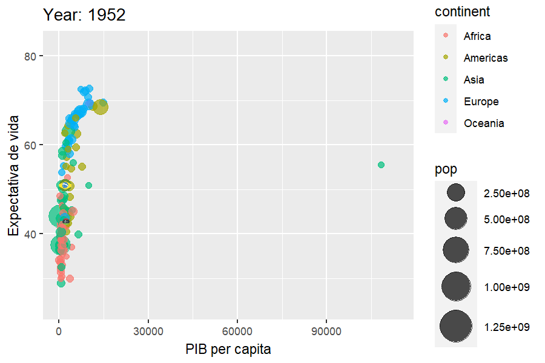

```r
data( "gapminder" )
lybia <- filter( gapminder, country == "Libya" )
brasil <- filter( gapminder, country == "Brazil" )

g <- ggplot( gapminder,
             aes(gdpPercap, lifeExp, size = pop, color=continent, frame = year)) +
  geom_point( alpha = 0.7 ) +
  scale_size( range = c(2, 12) ) +
  labs( title = 'Year: {frame_time}',
        x = 'PIB per capita',
        y = 'Expectativa de vida' ) +
  transition_time( year ) +
  geom_flag( data=brasil, country="br", show.legend=F ) +
  geom_flag( data=lybia, country="ly", show.legend=F )

animate( g,
         height = 4, width = 6, units = "in",
         nframes=100, fps=10, res = 150,
         duration = 5, start_pause=5, end_pause=25 )
```

12. Ao invés de comparar o Brasil (br) à Líbia (ly) apenas, vamos compará-lo a um país de cada continente(Reino Unido (gb), China (cn), Africa do Sul (za) e Nova Zelândia(nz)). Além disso a animação está muito rápida e a escala original não favorece muito a nossa visualização, por isso aumente a duração da animação para 15 segundos e mude a escala dos eixos para `log10`. Pode demorar um pouco para renderizar.